# FINAL

Maxi Ahl

2026-02-05

```r
library(terra)      # Reading and manipulating raster data
library(sf)         # Reading and manipulating vector data
library(dplyr)      # Manipulating data.frames
```

```r
library(ggplot2)    # Visualization
library(spatstat)   # Point Pattern Analysis
library(ggplot2)    # data visualizatio
library(tidyr)      # data wrangling package: change from wide to long format
library(dplyr)      # data manipulation: mutate
library(gridExtra)  # plot multiple ggplot graphs
library(caret)      # cross-validation
library(mapview)    # Map visualization
library(gstat)      # geostatistics
library(stars)      # spatial-temporal data
library(abind)
library(spdep)      # Diagnosing spatial dependence
library(spatialreg) # Spatial lag and spatial error model
library(readxl)
library(raster)
library(ggcorrplot)
library(reshape2)
library(pracma)
library(data.table)
library(stringr)
library(readr)
library(corrplot)
library(broom)
library(spatialreg)
```

LOAD IN FINAL GPKG

```r
FULL <- st_read("/Users/maxi_161/Desktop/UNI/Master/THESIS/DATEN + GIS/ANALYSIS.nosync/gemeinden_elbe_final_full.gpkg")
glimpse(FULL)
```

```
## Rows: 2,542
## Columns: 170
## $ OBJECTID                                      <dbl> 2, 2, 2, 2, 2, 2, 2, 2, …
## $ id                                            <dbl> 2, 4, 5, 7, 8, 9, 10, 11…
## $ Objektidentifikator                           <chr> "DEBKGVG200000009", "DEB…
## $ Geofaktor_GF                                  <chr> "mit Struktur Land", "mi…
## $ GF                                            <int> 4, 4, 4, 4, 4, 4, 4, 4, …
## $ Besondere_Gebiete_BSG                         <chr> "Deutschland", "Deutschl…
## $ BSG                                           <int> 1, 1, 1, 1, 1, 1, 1, 1, …
## $ Länderkürzel_LKZ                              <chr> "SH", "SH", "SH", "SH", …
## $ Gemeindeschlüssel_AGS                         <chr> "01002000", "01004000", …
## $ Verwaltungssitz_SDV_ARS                       <chr> "010020000000", "0100400…
## $ GeografischerName_GEN                         <chr> "Kiel", "Neumünster", "B…
## $ Bezeichnung                                   <chr> "Stadt", "Stadt", "Stadt…
## $ Identifikator_IBZ                             <int> 60, 60, 61, 64, 64, 64, …
```

[output cut: 157 more lines]

CHECKS Protection

```r
summary(FULL$share_protected)
```

```
##     Min.  1st Qu.   Median     Mean  3rd Qu.     Max.
## 0.000000 0.000000 0.004147 0.011048 0.015796 0.274057
```

Exposure

```r
summary(FULL$exposure_share_flood_total)
```

```
##     Min.  1st Qu.   Median     Mean  3rd Qu.     Max.
## 0.000000 0.000000 0.000000 0.026289 0.008896 0.994807
```

Kombination

```r
cor(FULL$share_protected,
    FULL$exposure_share_flood_total,
    use="complete.obs")
```

```
## [1] 0.01894241
```

Residual Risk

```r
FULL <- FULL %>%
  mutate(
    residual_risk =
      exposure_share_flood_total * (1 - share_protected)
  )
```

```r
summary(FULL$residual_risk)
```

```
##     Min.  1st Qu.   Median     Mean  3rd Qu.     Max.
## 0.000000 0.000000 0.000000 0.025971 0.008744 0.994807
```

```r
head(FULL)
```

```
## Simple feature collection with 6 features and 170 fields
## Geometry type: MULTIPOLYGON
## Dimension:     XY
## Bounding box:  xmin: 501147.4 ymin: 5970993 xmax: 574615.6 ymax: 6029068
## Projected CRS: ETRS89 / UTM zone 32N
##   OBJECTID id Objektidentifikator      Geofaktor_GF GF Besondere_Gebiete_BSG
## 1        2  2    DEBKGVG200000009 mit Struktur Land  4           Deutschland
## 2        2  4    DEBKGVG20000000B mit Struktur Land  4           Deutschland
## 3        2  5    DEBKGVG20000000C mit Struktur Land  4           Deutschland
## 4        2  7    DEBKGVG20000000E mit Struktur Land  4           Deutschland
## 5        2  8    DEBKGVG20000000F mit Struktur Land  4           Deutschland
## 6        2  9    DEBKGVG20000000G mit Struktur Land  4           Deutschland
##   BSG Länderkürzel_LKZ Gemeindeschlüssel_AGS Verwaltungssitz_SDV_ARS
## 1   1               SH              01002000            010020000000
## 2   1               SH              01004000            010040000000
```

[output cut: 494 more lines]

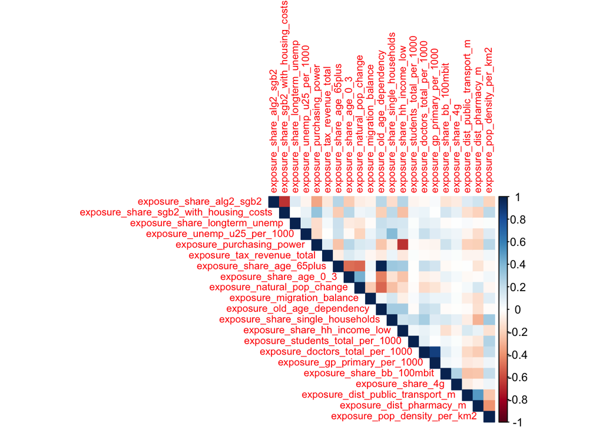

```r
vars <- FULL |>
  sf::st_drop_geometry() |>
  dplyr::select(
    exposure_share_alg2_sgb2,
    exposure_share_sgb2_with_housing_costs,
    exposure_share_longterm_unemp,
    exposure_unemp_u25_per_1000,
    exposure_purchasing_power,
    exposure_tax_revenue_total,
    exposure_share_age_65plus,
    exposure_share_age_0_3,
    exposure_natural_pop_change,
    exposure_migration_balance,
    exposure_old_age_dependency,
    exposure_share_single_households,
    exposure_share_hh_income_low,
    exposure_students_total_per_1000,
    exposure_doctors_total_per_1000,
    exposure_gp_primary_per_1000,
    exposure_share_bb_100mbit,
    exposure_share_4g,
    exposure_dist_public_transport_m,
    exposure_dist_pharmacy_m,
    exposure_pop_density_per_km2
  ) |>
  dplyr::mutate(
    dplyr::across(dplyr::everything(), ~ readr::parse_number(as.character(.x)))
  )

cor_mat <- cor(vars, use = "pairwise.complete.obs")
corrplot::corrplot(cor_mat, method = "color", type = "upper", tl.cex = 0.7)
```

RESIDUAL RISK CONCEPT Zone 1 = offizielles Überschwemmungsgebiet

→ regelmäßig betroffen → gesetzlich festgesetzt → ohne Schutzmaßnahme

Zone 3 = hochwassergeschütztes Gebiet

→ liegt hinter Deichen → wäre ohne Deich im Überflutungsgebiet → wird aber in Extremereignissen modelliert

Unprotected flood exposure = zone1 Protected flood exposure = zone3 Total flood exposure = zone1 + zone2 + zone3

# 1) Make sure zone shares exist and NAs are 0

```r
FULL <- FULL %>%
  mutate(
    exposure_share_flood_total = if_else(is.na(exposure_share_flood_total), 0, exposure_share_flood_total),
    exposure_share_flood_zone1 = if_else(is.na(exposure_share_flood_zone1), 0, exposure_share_flood_zone1),
    exposure_share_flood_zone2 = if_else(is.na(exposure_share_flood_zone2), 0, exposure_share_flood_zone2),
    exposure_share_flood_zone3 = if_else(is.na(exposure_share_flood_zone3), 0, exposure_share_flood_zone3)
  )
```

# 2) Define core outcomes

```r
FULL <- FULL %>%
  mutate(
    share_total_hazard = exposure_share_flood_total,
    share_unprotected  = exposure_share_flood_zone1,
    share_informational = exposure_share_flood_zone2,
    share_protected_hazard = exposure_share_flood_zone3,

    # Residual risk (supervisor-consistent): what is unprotected in HQ100
    residual_risk = share_unprotected,

    # How much of the hazard footprint is classified as protected (avoid /0)
    protection_share_of_hazard = if_else(
      share_total_hazard > 0,
      share_protected_hazard / share_total_hazard,
      NA_real_
    )
  )
```

# 3) Sanity checks

```r
summary(FULL$share_total_hazard)
```

```
##     Min.  1st Qu.   Median     Mean  3rd Qu.     Max.
## 0.000000 0.000000 0.000000 0.026289 0.008896 0.994807
```

```r
summary(FULL$share_unprotected)
```

```
##     Min.  1st Qu.   Median     Mean  3rd Qu.     Max.
## 0.000000 0.000000 0.000000 0.025804 0.008518 0.994807
```

```r
summary(FULL$share_protected_hazard)
```

```
##      Min.   1st Qu.    Median      Mean   3rd Qu.      Max.
## 0.0000000 0.0000000 0.0000000 0.0001219 0.0000000 0.1163415
```

```r
summary(FULL$protection_share_of_hazard)
```

```
##    Min. 1st Qu.  Median    Mean 3rd Qu.    Max.    NA's
## 0.00000 0.00000 0.00000 0.00335 0.00000 1.00000    1640
```

# Optional quick check: do zone parts roughly add up to total?

```r
check_diff <- FULL %>%
  st_drop_geometry() %>%
  transmute(
    diff = share_total_hazard - (share_unprotected + share_informational + share_protected_hazard)
  )

summary(check_diff$diff)
```

```
##       Min.    1st Qu.     Median       Mean    3rd Qu.       Max.
## -1.388e-17  0.000e+00  0.000e+00  2.252e-20  0.000e+00  5.551e-17
```

WIDE PCA (Principal Component Analysis) # 1. Extract all socio-economic vars

```r
names(FULL)
```

```
##   [1] "OBJECTID"
##   [2] "id"
##   [3] "Objektidentifikator"
##   [4] "Geofaktor_GF"
##   [5] "GF"
##   [6] "Besondere_Gebiete_BSG"
##   [7] "BSG"
##   [8] "Länderkürzel_LKZ"
##   [9] "Gemeindeschlüssel_AGS"
##  [10] "Verwaltungssitz_SDV_ARS"
##  [11] "GeografischerName_GEN"
##  [12] "Bezeichnung"
##  [13] "Identifikator_IBZ"
##  [14] "Land"
##  [15] "Regierungsbezirk"
```

[output cut: 161 more lines]

```r
wide_pca_vars <- FULL %>%
  sf::st_drop_geometry() %>%
  dplyr::select(

    # Poverty / Welfare
    exposure_share_alg2_sgb2,
    exposure_share_bg_single_parent,
    exposure_share_bg_5plus,
    exposure_share_bg_with_children,
    exposure_share_sgb2_with_housing_costs,

    # Unemployment
    exposure_share_longterm_unemp,
    exposure_unemp_u25_per_1000,
    exposure_unemp_55plus_per_1000,

    # Income / Fiscal
    exposure_income_tax_per_capita,
    exposure_purchasing_power,
    exposure_trade_tax_per_capita,
    exposure_tax_revenue_total,

    # Demography
    exposure_share_age_0_3,
    exposure_share_age_3_6,
    exposure_share_age_6_18,
    exposure_share_age_18_25,
    exposure_share_age_25_30,
    exposure_share_age_30_50,
    exposure_share_age_50_65,
    exposure_share_age_65_75,
    exposure_share_age_65plus,
    exposure_share_age_75plus,

    # Population dynamics
    exposure_natural_pop_change,
    exposure_migration_balance,

    # Dependency
    exposure_old_age_dependency,
    exposure_youth_dependency,
    exposure_young_old_ratio,

    # Household
    exposure_share_single_households,
    exposure_share_households_with_children,

    # Income / education
    exposure_share_hh_income_high,
    exposure_share_hh_income_medium,
    exposure_share_hh_income_low,
    exposure_students_total_per_1000,
    exposure_students_18_25_per_1000,
    exposure_students_fh_per_1000,

    # Health
    exposure_gp_general_per_1000,
    exposure_gp_primary_per_1000,
    exposure_internists_per_1000,
    exposure_pediatricians_per_1000_children,
    exposure_doctors_total_per_1000,

    # Digital
    exposure_share_bb_1000mbit,
    exposure_share_bb_100mbit,
    exposure_share_bb_50mbit,
    exposure_share_4g,

    # Accessibility
    exposure_dist_supermarket_m,
    exposure_dist_pharmacy_m,
    exposure_dist_gp_m,
    exposure_dist_public_transport_m,
    exposure_dist_primary_school_m,

    # Density
    exposure_pop_density_per_km2,
    exposure_employment_density_per_km2
  ) %>%
  mutate(across(everything(), as.numeric)) %>%
  rename_with(~ stringr::str_remove(.x, "^exposure_"))
```

```r
names(wide_pca_vars)
```

```
##  [1] "share_alg2_sgb2"                 "share_bg_single_parent"
##  [3] "share_bg_5plus"                  "share_bg_with_children"
##  [5] "share_sgb2_with_housing_costs"   "share_longterm_unemp"
##  [7] "unemp_u25_per_1000"              "unemp_55plus_per_1000"
##  [9] "income_tax_per_capita"           "purchasing_power"
## [11] "trade_tax_per_capita"            "tax_revenue_total"
## [13] "share_age_0_3"                   "share_age_3_6"
## [15] "share_age_6_18"                  "share_age_18_25"
## [17] "share_age_25_30"                 "share_age_30_50"
## [19] "share_age_50_65"                 "share_age_65_75"
## [21] "share_age_65plus"                "share_age_75plus"
## [23] "natural_pop_change"              "migration_balance"
## [25] "old_age_dependency"              "youth_dependency"
## [27] "young_old_ratio"                 "share_single_households"
## [29] "share_households_with_children"  "share_hh_income_high"
## [31] "share_hh_income_medium"          "share_hh_income_low"
## [33] "students_total_per_1000"         "students_18_25_per_1000"
## [35] "students_fh_per_1000"            "gp_general_per_1000"
## [37] "gp_primary_per_1000"             "internists_per_1000"
## [39] "pediatricians_per_1000_children" "doctors_total_per_1000"
## [41] "share_bb_1000mbit"               "share_bb_100mbit"
## [43] "share_bb_50mbit"                 "share_4g"
## [45] "dist_supermarket_m"              "dist_pharmacy_m"
## [47] "dist_gp_m"                       "dist_public_transport_m"
## [49] "dist_primary_school_m"           "pop_density_per_km2"
## [51] "employment_density_per_km2"
```

```r
wide_pca_clean <- wide_pca_vars %>% drop_na()
wide_pca_scaled <- scale(wide_pca_clean)

wide_pca <- prcomp(wide_pca_scaled)

summary(wide_pca)
```

```
## Importance of components:
##                           PC1    PC2     PC3     PC4     PC5     PC6     PC7
## Standard deviation     2.8690 2.6185 1.85881 1.73450 1.49418 1.46733 1.43521
## Proportion of Variance 0.1614 0.1344 0.06775 0.05899 0.04378 0.04222 0.04039
## Cumulative Proportion  0.1614 0.2958 0.36358 0.42257 0.46635 0.50857 0.54896
##                            PC8     PC9   PC10    PC11    PC12   PC13    PC14
## Standard deviation     1.34403 1.27640 1.2140 1.13674 1.09139 1.0300 1.01226
## Proportion of Variance 0.03542 0.03194 0.0289 0.02534 0.02336 0.0208 0.02009
## Cumulative Proportion  0.58438 0.61632 0.6452 0.67056 0.69391 0.7147 0.73480
##                           PC15    PC16    PC17    PC18    PC19    PC20    PC21
## Standard deviation     0.99417 0.98409 0.94880 0.94503 0.89118 0.86380 0.86222
## Proportion of Variance 0.01938 0.01899 0.01765 0.01751 0.01557 0.01463 0.01458
## Cumulative Proportion  0.75418 0.77317 0.79082 0.80833 0.82391 0.83854 0.85311
##                          PC22    PC23    PC24    PC25    PC26   PC27   PC28
## Standard deviation     0.7889 0.78162 0.75302 0.73629 0.72584 0.6924 0.6546
## Proportion of Variance 0.0122 0.01198 0.01112 0.01063 0.01033 0.0094 0.0084
## Cumulative Proportion  0.8653 0.87730 0.88842 0.89905 0.90938 0.9188 0.9272
##                           PC29    PC30    PC31    PC32    PC33    PC34    PC35
## Standard deviation     0.64785 0.60120 0.59267 0.54527 0.54153 0.51965 0.50382
## Proportion of Variance 0.00823 0.00709 0.00689 0.00583 0.00575 0.00529 0.00498
## Cumulative Proportion  0.93541 0.94249 0.94938 0.95521 0.96096 0.96626 0.97123
##                           PC36    PC37    PC38    PC39    PC40    PC41    PC42
## Standard deviation     0.49605 0.49070 0.46980 0.42472 0.41308 0.37213 0.35337
## Proportion of Variance 0.00482 0.00472 0.00433 0.00354 0.00335 0.00272 0.00245
## Cumulative Proportion  0.97606 0.98078 0.98511 0.98864 0.99199 0.99470 0.99715
##                           PC43    PC44    PC45   PC46    PC47    PC48     PC49
## Standard deviation     0.28013 0.18181 0.10567 0.1019 0.08031 0.07541 0.001418
## Proportion of Variance 0.00154 0.00065 0.00022 0.0002 0.00013 0.00011 0.000000
## Cumulative Proportion  0.99869 0.99934 0.99956 0.9998 0.99989 1.00000 1.000000
##                             PC50      PC51
## Standard deviation     0.0008076 0.0005325
## Proportion of Variance 0.0000000 0.0000000
## Cumulative Proportion  1.0000000 1.0000000
```

```r
round(wide_pca$rotation[,1:5], 3)
```

```
##                                    PC1    PC2    PC3    PC4    PC5
## share_alg2_sgb2                  0.174  0.083  0.140 -0.042  0.049
## share_bg_single_parent           0.103  0.025  0.025 -0.023  0.025
## share_bg_5plus                  -0.094 -0.032 -0.029  0.018 -0.016
## share_bg_with_children          -0.125 -0.052 -0.016  0.047 -0.014
## share_sgb2_with_housing_costs   -0.160 -0.107 -0.155  0.022 -0.053
## share_longterm_unemp             0.089 -0.050  0.036 -0.048  0.037
## unemp_u25_per_1000               0.048 -0.141 -0.024 -0.048 -0.003
## unemp_55plus_per_1000            0.143 -0.114  0.035 -0.102  0.068
## income_tax_per_capita           -0.256  0.030 -0.198  0.113 -0.056
## purchasing_power                -0.215 -0.049 -0.141  0.177  0.000
## trade_tax_per_capita            -0.035 -0.012 -0.022 -0.051  0.101
## tax_revenue_total               -0.061 -0.010 -0.046 -0.041  0.091
## share_age_0_3                   -0.200  0.053  0.054 -0.031 -0.044
## share_age_3_6                   -0.157  0.076  0.215 -0.005  0.048
## share_age_6_18                  -0.125  0.084  0.352  0.011  0.090
## share_age_18_25                 -0.187 -0.089 -0.116 -0.125 -0.041
## share_age_25_30                 -0.193 -0.080 -0.149 -0.118 -0.085
## share_age_30_50                 -0.185  0.096  0.251 -0.098  0.039
## share_age_50_65                  0.073  0.167 -0.310  0.051 -0.165
## share_age_65_75                  0.287 -0.011  0.019  0.046  0.071
## share_age_65plus                 0.277 -0.166 -0.043  0.095  0.086
## share_age_75plus                 0.155 -0.255 -0.088  0.107  0.066
## natural_pop_change              -0.154  0.149  0.061 -0.069 -0.046
## migration_balance               -0.022 -0.091  0.022  0.029  0.004
## old_age_dependency               0.267 -0.166 -0.003  0.104  0.103
## youth_dependency                -0.117  0.047  0.392  0.045  0.109
## young_old_ratio                 -0.183 -0.029  0.119 -0.058  0.054
## share_single_households          0.052 -0.254 -0.132 -0.100  0.001
## share_households_with_children  -0.120  0.245  0.194  0.027  0.004
## share_hh_income_high            -0.233 -0.037 -0.194  0.154 -0.037
## share_hh_income_medium           0.113  0.071  0.173 -0.043  0.014
## share_hh_income_low              0.202 -0.013  0.100 -0.161  0.036
## students_total_per_1000         -0.029 -0.113 -0.003 -0.482 -0.097
## students_18_25_per_1000         -0.028 -0.114 -0.003 -0.472 -0.094
## students_fh_per_1000            -0.018 -0.087 -0.008 -0.445 -0.101
## gp_general_per_1000              0.042 -0.104  0.158  0.127 -0.514
## gp_primary_per_1000              0.045 -0.127  0.180  0.125 -0.531
## internists_per_1000              0.007 -0.157  0.018 -0.036  0.052
## pediatricians_per_1000_children  0.015 -0.147  0.021  0.001  0.064
## doctors_total_per_1000           0.034 -0.198  0.173  0.075 -0.445
## share_bb_1000mbit               -0.213 -0.107 -0.149  0.045  0.004
## share_bb_100mbit                -0.090 -0.140 -0.026  0.093  0.074
## share_bb_50mbit                 -0.075 -0.123 -0.015  0.099  0.054
## share_4g                        -0.023 -0.037 -0.029  0.015 -0.017
## dist_supermarket_m               0.065  0.265 -0.105 -0.083 -0.111
## dist_pharmacy_m                  0.079  0.267 -0.091 -0.074 -0.168
## dist_gp_m                        0.062  0.264 -0.175 -0.114  0.026
## dist_public_transport_m          0.086  0.163 -0.139 -0.097 -0.114
## dist_primary_school_m            0.080  0.244 -0.158 -0.088 -0.110
## pop_density_per_km2             -0.111 -0.216  0.022 -0.104  0.086
## employment_density_per_km2      -0.107 -0.220  0.023 -0.126  0.084
```

# —- PCA Loadings Table —-

```r
loadings <- as.data.frame(wide_pca$rotation)
loadings$variable <- rownames(loadings)

# Long format
loadings_long <- loadings %>%
  pivot_longer(
    cols = starts_with("PC"),
    names_to = "PC",
    values_to = "loading"
  ) %>%
  mutate(abs_loading = abs(loading))

# Top 8 variables per PC
top_loadings <- loadings_long %>%
  group_by(PC) %>%
  arrange(desc(abs_loading)) %>%
  slice_head(n = 8) %>%
  ungroup()

# View
top_loadings %>%
  arrange(PC, desc(abs_loading))
```

```
## # A tibble: 408 × 4
##    variable              PC    loading abs_loading
##    <chr>                 <chr>   <dbl>       <dbl>
##  1 share_age_65_75       PC1     0.287       0.287
##  2 share_age_65plus      PC1     0.277       0.277
##  3 old_age_dependency    PC1     0.267       0.267
##  4 income_tax_per_capita PC1    -0.256       0.256
##  5 share_hh_income_high  PC1    -0.233       0.233
##  6 purchasing_power      PC1    -0.215       0.215
##  7 share_bb_1000mbit     PC1    -0.213       0.213
##  8 share_hh_income_low   PC1     0.202       0.202
##  9 youth_dependency      PC10    0.295       0.295
## 10 share_age_18_25       PC10   -0.290       0.290
## # ℹ 398 more rows
```

# —- Scree Plot —-

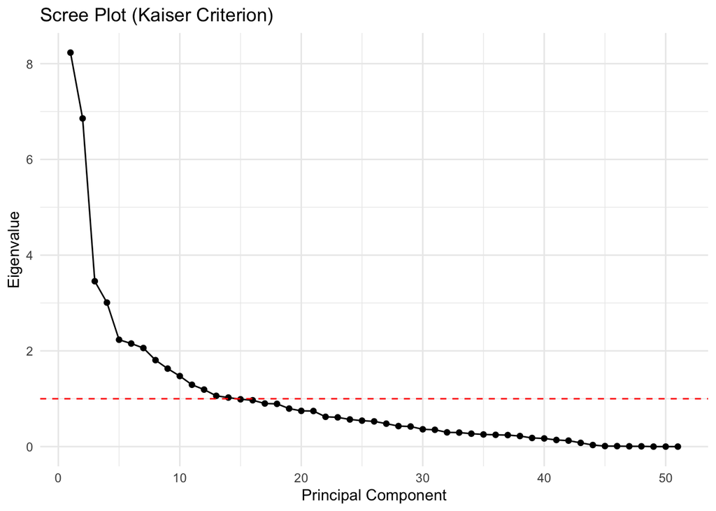

```r
pca_var <- wide_pca$sdev^2
pca_var_prop <- pca_var / sum(pca_var)

scree_df <- data.frame(
  PC = seq_along(pca_var),
  Eigenvalue = pca_var,
  Variance = pca_var_prop,
  Cumulative = cumsum(pca_var_prop)
)

ggplot(scree_df, aes(x = PC, y = Eigenvalue)) +
  geom_line() +
  geom_point() +
  geom_hline(yintercept = 1, linetype = "dashed", color = "red") +
  labs(
    title = "Scree Plot (Kaiser Criterion)",
    x = "Principal Component",
    y = "Eigenvalue"
  ) +
  theme_minimal()
```

Kaiser-Kriterium (Standard)

```r
scree_df %>%
  filter(Eigenvalue > 1)
```

```
##    PC Eigenvalue   Variance Cumulative
## 1   1   8.231194 0.16139596  0.1613960
## 2   2   6.856454 0.13444027  0.2958362
## 3   3   3.455169 0.06774841  0.3635846
## 4   4   3.008498 0.05899015  0.4225748
## 5   5   2.232577 0.04377602  0.4663508
## 6   6   2.153056 0.04221678  0.5085676
## 7   7   2.059820 0.04038863  0.5489562
## 8   8   1.806412 0.03541984  0.5843761
## 9   9   1.629189 0.03194488  0.6163209
## 10 10   1.473761 0.02889727  0.6452182
## 11 11   1.292180 0.02533686  0.6705551
## 12 12   1.191124 0.02335538  0.6939104
## 13 13   1.060865 0.02080127  0.7147117
## 14 14   1.024661 0.02009139  0.7348031
```

Cumulative Variance Check

```r
scree_df %>%
  filter(Cumulative <= 0.7)
```

```
##    PC Eigenvalue   Variance Cumulative
## 1   1   8.231194 0.16139596  0.1613960
## 2   2   6.856454 0.13444027  0.2958362
## 3   3   3.455169 0.06774841  0.3635846
## 4   4   3.008498 0.05899015  0.4225748
## 5   5   2.232577 0.04377602  0.4663508
## 6   6   2.153056 0.04221678  0.5085676
## 7   7   2.059820 0.04038863  0.5489562
## 8   8   1.806412 0.03541984  0.5843761
## 9   9   1.629189 0.03194488  0.6163209
## 10 10   1.473761 0.02889727  0.6452182
## 11 11   1.292180 0.02533686  0.6705551
## 12 12   1.191124 0.02335538  0.6939104
```

Hauptindex: PC1–PC8 Sensitivity: PC1–PC12

Hauptversion (PC1–PC8):

```r
# --- PCA scores back into FULL (matches the drop_na rows) ---

# which rows were kept for PCA?
rows_kept <- complete.cases(wide_pca_vars)   # logical vector length nrow(FULL)

# create empty PC columns in FULL
k <- ncol(wide_pca$x)                        # number of PCs (51)
pc_names <- paste0("PC", 1:k)

FULL[, pc_names] <- NA_real_

# fill only the kept rows with the PCA scores
FULL[rows_kept, pc_names] <- wide_pca$x
```

```r
names(FULL)[grepl("^PC\\d+$", names(FULL))] |> head()
```

```
## [1] "PC1" "PC2" "PC3" "PC4" "PC5" "PC6"
```

```r
summary(FULL$PC1)
```

```
##     Min.  1st Qu.   Median     Mean  3rd Qu.     Max.     NA's
## -15.1750  -2.0345   0.4999   0.0000   2.0759  11.2285       78
```

```r
sum(!is.na(FULL$PC1))
```

```
## [1] 2464
```

INDEX BAUEN (Hauptindex PC1–PC8)

```r
k_main <- 8
weights_main <- scree_df$Variance[1:k_main]
names(weights_main) <- paste0("PC", 1:k_main)

pc_mat <- FULL |>
  sf::st_drop_geometry() |>
  dplyr::select(dplyr::all_of(names(weights_main))) |>
  as.matrix()

FULL$vuln_index_main <- as.numeric(pc_mat %*% weights_main)
summary(FULL$vuln_index_main)
```

```
##    Min. 1st Qu.  Median    Mean 3rd Qu.    Max.    NA's
## -5.4120 -0.3824  0.0670  0.0000  0.4290  1.8095      78
```

standardisieren, damit es “schön” ist (Mean 0, SD 1):

```r
FULL$vuln_index_main_z <- as.numeric(scale(FULL$vuln_index_main))
summary(FULL$vuln_index_main_z)
```

```
##    Min. 1st Qu.  Median    Mean 3rd Qu.    Max.    NA's
## -8.7979 -0.6217  0.1089  0.0000  0.6974  2.9416      78
```

Analyse-DF + ein paar Safety-Fixes

```r
# working copy without geometry for regressions
df <- FULL |>
  sf::st_drop_geometry() |>
  mutate(
    vuln = vuln_index_main_z,                 # dein Index (z)
    prot = share_protected,                   # protection share of municipality
    risk = residual_risk                      # outcome
  ) |>
  filter(!is.na(vuln), !is.na(prot), !is.na(risk))

summary(df$risk)
```

```
##    Min. 1st Qu.  Median    Mean 3rd Qu.    Max.
## 0.00000 0.00000 0.00000 0.02657 0.00921 0.99481
```

```r
summary(df$vuln)
```

```
##    Min. 1st Qu.  Median    Mean 3rd Qu.    Max.
## -8.7979 -0.6217  0.1089  0.0000  0.6974  2.9416
```

```r
summary(df$prot)
```

```
##     Min.  1st Qu.   Median     Mean  3rd Qu.     Max.
## 0.000000 0.000000 0.004546 0.011191 0.016194 0.274057
```

```r
# optional: logit-transform risk if it’s a share in [0,1]
# (only if you want; otherwise keep linear)
df <- df |>
  mutate(
    risk_eps = pmin(pmax(risk, 1e-6), 1 - 1e-6),
    logit_risk = log(risk_eps / (1 - risk_eps))
  )
```

2. Regression: Protection + Vulnerability (inkl. Interaction)

B1) Baseline OLS (linear)

```r
m1 <- lm(risk ~ vuln + prot, data = df)
m2 <- lm(risk ~ vuln * prot, data = df)   # interaction

summary(m1)
```

```
##
## Call:
## lm(formula = risk ~ vuln + prot, data = df)
##
## Residuals:
##      Min       1Q   Median       3Q      Max
## -0.03628 -0.02747 -0.02501 -0.01723  0.96549
##
## Coefficients:
##             Estimate Std. Error t value Pr(>|t|)
## (Intercept) 0.025945   0.001951  13.300   <2e-16 ***
## vuln        0.002117   0.001662   1.274    0.203
## prot        0.055490   0.093328   0.595    0.552
## ---
## Signif. codes:  0 '***' 0.001 '**' 0.01 '*' 0.05 '.' 0.1 ' ' 1
##
## Residual standard error: 0.08178 on 2461 degrees of freedom
## Multiple R-squared:  0.0008965,  Adjusted R-squared:  8.456e-05
## F-statistic: 1.104 on 2 and 2461 DF,  p-value: 0.3317
```

```r
summary(m2)
```

```
##
## Call:
## lm(formula = risk ~ vuln * prot, data = df)
##
## Residuals:
##      Min       1Q   Median       3Q      Max
## -0.07228 -0.02789 -0.02423 -0.01603  0.96036
##
## Coefficients:
##              Estimate Std. Error t value Pr(>|t|)
## (Intercept)  0.026182   0.001950  13.427  < 2e-16 ***
## vuln         0.005186   0.001995   2.599  0.00939 **
## prot         0.094804   0.094275   1.006  0.31470
## vuln:prot   -0.295095   0.106488  -2.771  0.00563 **
## ---
## Signif. codes:  0 '***' 0.001 '**' 0.01 '*' 0.05 '.' 0.1 ' ' 1
##
## Residual standard error: 0.08167 on 2460 degrees of freedom
## Multiple R-squared:  0.004006,   Adjusted R-squared:  0.002791
## F-statistic: 3.298 on 3 and 2460 DF,  p-value: 0.01965
```

```r
# nice table-like output
broom::tidy(m2, conf.int = TRUE)
```

```
## # A tibble: 4 × 7
##   term        estimate std.error statistic  p.value conf.low conf.high
##   <chr>          <dbl>     <dbl>     <dbl>    <dbl>    <dbl>     <dbl>
## 1 (Intercept)  0.0262    0.00195     13.4  1.02e-39  0.0224    0.0300
## 2 vuln         0.00519   0.00200      2.60 9.39e- 3  0.00127   0.00910
## 3 prot         0.0948    0.0943       1.01 3.15e- 1 -0.0901    0.280
## 4 vuln:prot   -0.295     0.106       -2.77 5.63e- 3 -0.504    -0.0863
```

```r
broom::glance(m2)
```

```
## # A tibble: 1 × 12
##   r.squared adj.r.squared  sigma statistic p.value    df logLik    AIC    BIC
##       <dbl>         <dbl>  <dbl>     <dbl>   <dbl> <dbl>  <dbl>  <dbl>  <dbl>
## 1   0.00401       0.00279 0.0817      3.30  0.0197     3  2678. -5346. -5317.
## # ℹ 3 more variables: deviance <dbl>, df.residual <int>, nobs <int>
```

B2) Wenn du “Shares” sauberer modellieren willst: logit(risk)

```r
m2_logit <- lm(logit_risk ~ vuln * prot, data = df)
summary(m2_logit)
```

```
##
## Call:
## lm(formula = logit_risk ~ vuln * prot, data = df)
##
## Residuals:
##    Min     1Q Median     3Q    Max
## -9.794 -3.296 -3.147  5.310 16.036
##
## Coefficients:
##              Estimate Std. Error t value Pr(>|t|)
## (Intercept) -10.65768    0.11735 -90.823  < 2e-16 ***
## vuln         -0.07717    0.12007  -0.643  0.52046
## prot         40.80809    5.67338   7.193 8.38e-13 ***
## vuln:prot   -20.32163    6.40834  -3.171  0.00154 **
## ---
## Signif. codes:  0 '***' 0.001 '**' 0.01 '*' 0.05 '.' 0.1 ' ' 1
##
## Residual standard error: 4.915 on 2460 degrees of freedom
## Multiple R-squared:  0.02394,    Adjusted R-squared:  0.02275
## F-statistic: 20.11 on 3 and 2460 DF,  p-value: 7.113e-13
```

```r
broom::tidy(m2_logit, conf.int = TRUE)
```

```
## # A tibble: 4 × 7
##   term        estimate std.error statistic  p.value conf.low conf.high
##   <chr>          <dbl>     <dbl>     <dbl>    <dbl>    <dbl>     <dbl>
## 1 (Intercept) -10.7        0.117   -90.8   0         -10.9     -10.4
## 2 vuln         -0.0772     0.120    -0.643 5.20e- 1   -0.313     0.158
## 3 prot         40.8        5.67      7.19  8.38e-13   29.7      51.9
## 4 vuln:prot   -20.3        6.41     -3.17  1.54e- 3  -32.9      -7.76
```

B3) Quick plots für Results (Interpretation)

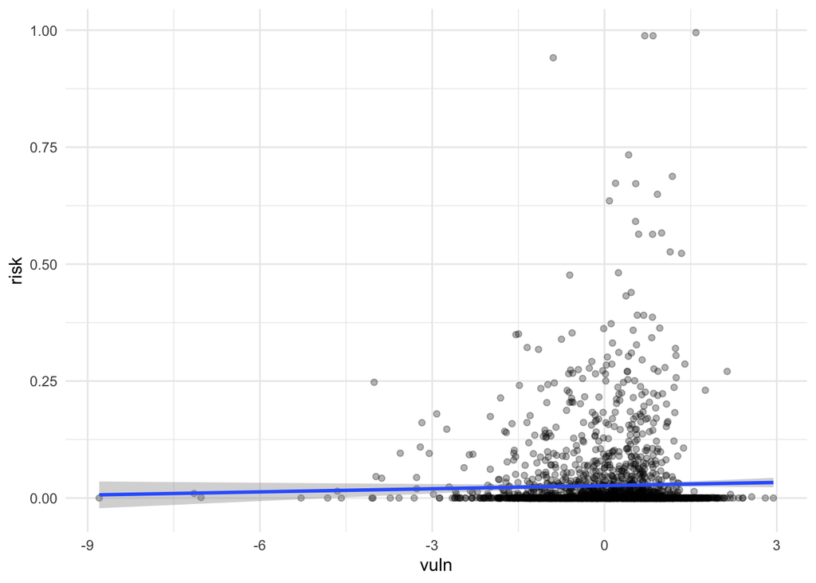

```r
# partial relationship plots
ggplot(df, aes(vuln, risk)) +
  geom_point(alpha = 0.3) +
  geom_smooth(method = "lm", se = TRUE) +
  theme_minimal()
```

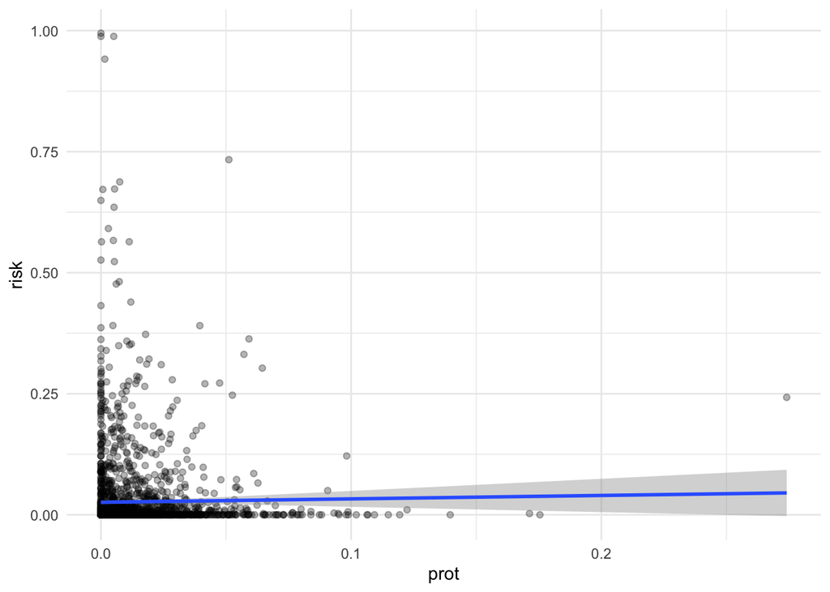

```r
ggplot(df, aes(prot, risk)) +
  geom_point(alpha = 0.3) +
  geom_smooth(method = "lm", se = TRUE) +
  theme_minimal()
```

B4) Spatial dependence check: Moran’s I auf Residuen

Wir testen, ob OLS Residuen räumlich autokorreliert sind → dann Spatial Model.

```r
# geometry back for spatial diagnostics
sf_dat <- FULL |>
  mutate(
    vuln = vuln_index_main_z,
    prot = share_protected,
    risk = residual_risk
  ) |>
  filter(!is.na(vuln), !is.na(prot), !is.na(risk))

# neighbors (queen contiguity)
nb <- poly2nb(sf_dat, queen = TRUE)
# weights
lw <- nb2listw(nb, style = "W", zero.policy = TRUE)

# residuals from OLS interaction model
ols <- lm(risk ~ vuln * prot, data = sf::st_drop_geometry(sf_dat))
e <- resid(ols)

moran.test(e, lw, zero.policy = TRUE)
```

```
##
##  Moran I test under randomisation
##
## data:  e
## weights: lw
## n reduced by no-neighbour observations
##
## Moran I statistic standard deviate = 44.364, p-value < 2.2e-16
## alternative hypothesis: greater
## sample estimates:
## Moran I statistic       Expectation          Variance
##      0.5582017591     -0.0004073320      0.0001585462
```

B5) Spatial regression: SAR (lag) und SEM (error)

```r
# SAR (spatial lag model)
sar <- spatialreg::lagsarlm(risk ~ vuln * prot, data = sf_dat, listw = lw, zero.policy = TRUE)
summary(sar)
```

```
##
## Call:spatialreg::lagsarlm(formula = risk ~ vuln * prot, data = sf_dat,
##     listw = lw, zero.policy = TRUE)
##
## Residuals:
##        Min         1Q     Median         3Q        Max
## -0.2575718 -0.0100730 -0.0043165 -0.0036349  0.7188668
##
## Type: lag
## Regions with no neighbours included:
##  773 774 775 777 778 781 782 800
## Coefficients: (asymptotic standard errors)
##                Estimate  Std. Error z value Pr(>|z|)
## (Intercept)  0.00407615  0.00134164  3.0382  0.00238
## vuln        -0.00021137  0.00133100 -0.1588  0.87382
## prot         0.09533796  0.06287782  1.5162  0.12946
## vuln:prot   -0.14147779  0.07101984 -1.9921  0.04636
##
## Rho: 0.79999, LR test value: 1578.8, p-value: < 2.22e-16
## Asymptotic standard error: 0.013714
##     z-value: 58.332, p-value: < 2.22e-16
## Wald statistic: 3402.6, p-value: < 2.22e-16
##
## Log likelihood: 3467.571 for lag model
## ML residual variance (sigma squared): 0.0029664, (sigma: 0.054465)
## Number of observations: 2464
## Number of parameters estimated: 6
## AIC: -6923.1, (AIC for lm: -5346.3)
## LM test for residual autocorrelation
## test value: 2.0113, p-value: 0.15613
```

```r
# SEM (spatial error model)
sem <- spatialreg::errorsarlm(risk ~ vuln * prot, data = sf_dat, listw = lw, zero.policy = TRUE)
summary(sem)
```

```
##
## Call:spatialreg::errorsarlm(formula = risk ~ vuln * prot, data = sf_dat,
##     listw = lw, zero.policy = TRUE)
##
## Residuals:
##        Min         1Q     Median         3Q        Max
## -0.2568832 -0.0102143 -0.0047961 -0.0013030  0.7231114
##
## Type: error
## Regions with no neighbours included:
##  773 774 775 777 778 781 782 800
## Coefficients: (asymptotic standard errors)
##               Estimate Std. Error z value  Pr(>|z|)
## (Intercept)  0.0229591  0.0053741  4.2722 1.936e-05
## vuln        -0.0035380  0.0016746 -2.1127   0.03463
## prot         0.1060341  0.0687332  1.5427   0.12291
## vuln:prot   -0.0976396  0.0703116 -1.3887   0.16493
##
## Lambda: 0.80143, LR test value: 1583.9, p-value: < 2.22e-16
## Asymptotic standard error: 0.013683
##     z-value: 58.573, p-value: < 2.22e-16
## Wald statistic: 3430.8, p-value: < 2.22e-16
##
## Log likelihood: 3470.093 for error model
## ML residual variance (sigma squared): 0.0029578, (sigma: 0.054386)
## Number of observations: 2464
## Number of parameters estimated: 6
## AIC: -6928.2, (AIC for lm: -5346.3)
```

```r
# compare AIC
AIC(ols, sar, sem)
```

```
##     df       AIC
## ols  5 -5346.328
## sar  6 -6923.143
## sem  6 -6928.187
```

3. Spatial clustering (Hotspots)

C1) Local Moran (LISA) für residual_risk

```r
lisa <- localmoran(sf_dat$risk, lw, zero.policy = TRUE)

sf_dat$lisa_I <- lisa[, "Ii"]
sf_dat$lisa_p <- lisa[, "Pr(z != E(Ii))"]

# simple hotspot flag (p < 0.05 and positive Ii)
sf_dat$hotspot <- sf_dat$lisa_p < 0.05 & sf_dat$lisa_I > 0
table(sf_dat$hotspot, useNA = "ifany")
```

```
##
## FALSE  TRUE
##  2292   172
```

Map:

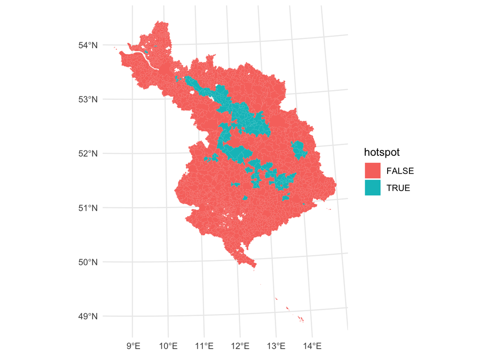

```r
ggplot(sf_dat) +
  geom_sf(aes(fill = hotspot), color = NA) +
  theme_minimal()
```

D) Map all PCs (und/oder Top 4)

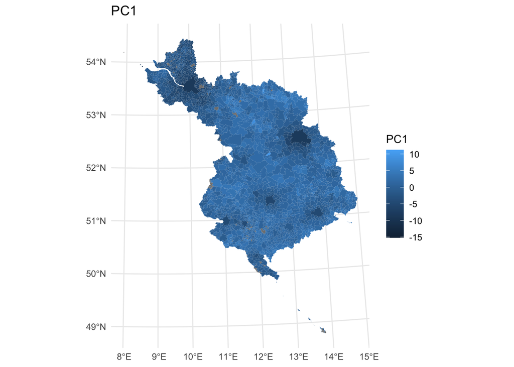

```r
pc_to_map <- paste0("PC", 1:4)

p_list <- lapply(pc_to_map, function(pc) {
  ggplot(FULL) +
    geom_sf(aes(fill = .data[[pc]]), color = NA) +
    labs(title = pc) +
    theme_minimal()
})

# show one by one
p_list[[1]]
```

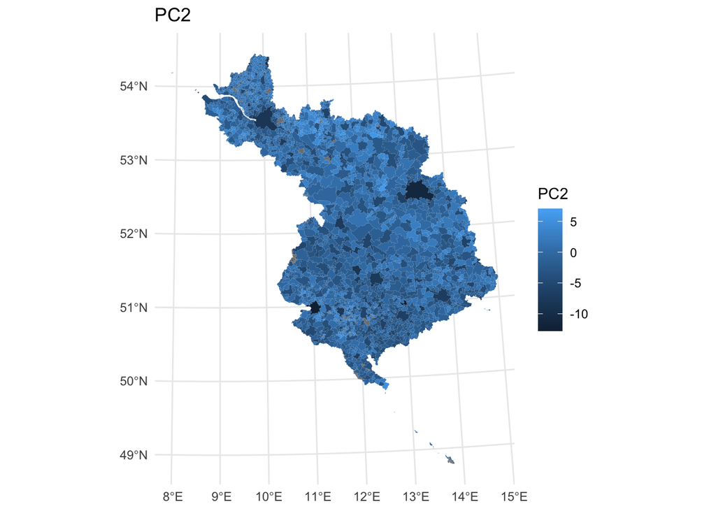

```r
p_list[[2]]
```

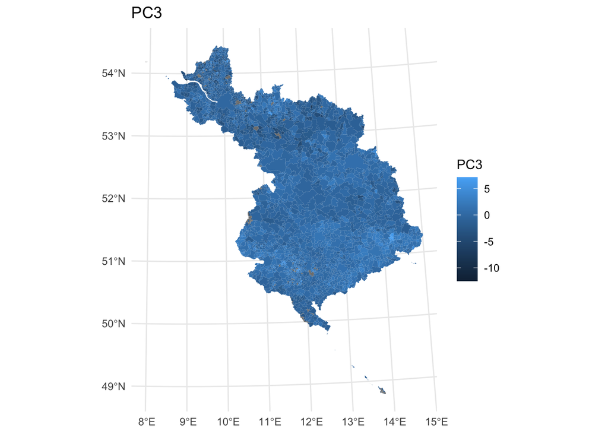

```r
p_list[[3]]
```

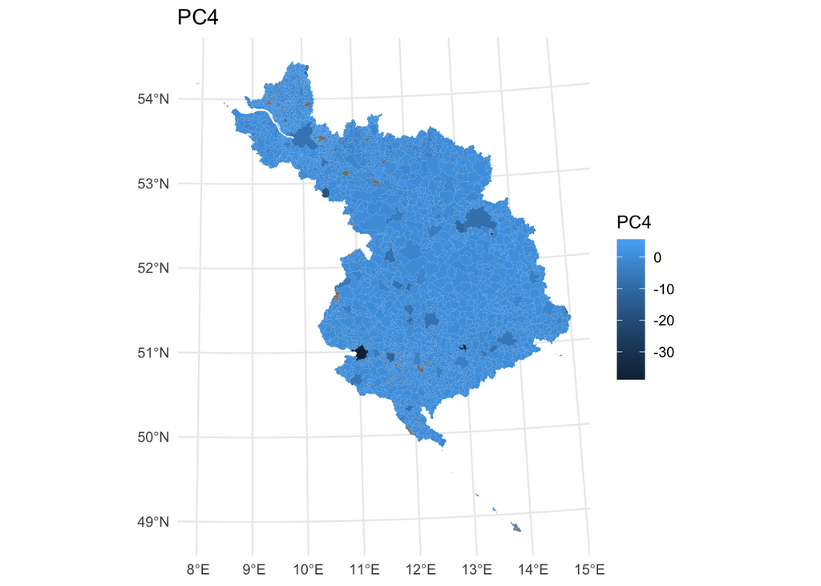

```r
p_list[[4]]
```

PC-Scores für ALLE Gemeinden berechnen (ohne drop_na-Desaster)

```r
# 1) Basis: gleiche Variablen wie im PCA
wide_pca_vars <- FULL %>%
  sf::st_drop_geometry() %>%
  dplyr::select(
    # Poverty / Welfare
    exposure_share_alg2_sgb2,
    exposure_share_bg_single_parent,
    exposure_share_bg_5plus,
    exposure_share_bg_with_children,
    exposure_share_sgb2_with_housing_costs,

    # Unemployment
    exposure_share_longterm_unemp,
    exposure_unemp_u25_per_1000,
    exposure_unemp_55plus_per_1000,

    # Income / Fiscal
    exposure_income_tax_per_capita,
    exposure_purchasing_power,
    exposure_trade_tax_per_capita,
    exposure_tax_revenue_total,

    # Demography
    exposure_share_age_0_3,
    exposure_share_age_3_6,
    exposure_share_age_6_18,
    exposure_share_age_18_25,
    exposure_share_age_25_30,
    exposure_share_age_30_50,
    exposure_share_age_50_65,
    exposure_share_age_65_75,
    exposure_share_age_65plus,
    exposure_share_age_75plus,

    # Population dynamics
    exposure_natural_pop_change,
    exposure_migration_balance,

    # Dependency
    exposure_old_age_dependency,
    exposure_youth_dependency,
    exposure_young_old_ratio,

    # Household
    exposure_share_single_households,
    exposure_share_households_with_children,

    # Income / education
    exposure_share_hh_income_high,
    exposure_share_hh_income_medium,
    exposure_share_hh_income_low,
    exposure_students_total_per_1000,
    exposure_students_18_25_per_1000,
    exposure_students_fh_per_1000,

    # Health
    exposure_gp_general_per_1000,
    exposure_gp_primary_per_1000,
    exposure_internists_per_1000,
    exposure_pediatricians_per_1000_children,
    exposure_doctors_total_per_1000,

    # Digital
    exposure_share_bb_1000mbit,
    exposure_share_bb_100mbit,
    exposure_share_bb_50mbit,
    exposure_share_4g,

    # Accessibility
    exposure_dist_supermarket_m,
    exposure_dist_pharmacy_m,
    exposure_dist_gp_m,
    exposure_dist_public_transport_m,
    exposure_dist_primary_school_m,

    # Density
    exposure_pop_density_per_km2,
    exposure_employment_density_per_km2
  ) %>%
  dplyr::mutate(dplyr::across(dplyr::everything(), as.numeric)) %>%
  dplyr::rename_with(~ stringr::str_remove(.x, "^exposure_"))


# 2) Imputation statt drop_na: median pro Variable (robust & simpel)
impute_median <- function(x) { x[is.na(x)] <- median(x, na.rm = TRUE); x }
wide_pca_imp <- wide_pca_vars %>%
  dplyr::mutate(dplyr::across(dplyr::everything(), impute_median))

# 3) PCA auf imputierten Daten (alles gleiche Länge wie FULL)
wide_pca_scaled <- scale(wide_pca_imp)
wide_pca <- prcomp(wide_pca_scaled)

# 4) PC Scores für ALLE Zeilen (N = 2542)
pc_scores <- as.data.frame(wide_pca$x)
names(pc_scores) <- paste0("PC", seq_len(ncol(pc_scores)))
```

2. PC-Spalten an FULL dranhängen

```r
FULL <- dplyr::bind_cols(FULL, pc_scores)
```